# Monte Carlo Methods

Karanpreet Benipal

2025-11-15

### Introduction

The purpose of this blog is to explore some advanced Monte Carlo techniques. I only learned basic Monte Carlo during my undergrad and found it to be interesting and fun! I wanted to learn more and decided that making a blog trying to explain these methods to someone else would a good way to learn for myself. I have found that this is an active area of research with room for new ideas. Maybe I (or you) will contribute something to this research one day.  
Basic Monte Carlo involves generating samples from a distribution, and then using those samples to calculate some quantity. What if you cannot sample directly from the distribution you are interested in? It may be very computationally expensive, or just impossible. This is where Markov Chain Monte Carlo (MCMC) and it’s extension Hamiltonian Monte Carlo (HMC) come in handy. This has many applications in Bayesian Inference, however for this blog we will restrict ourselves to just the techniques for sampling. I will present these algorithms and their variations, show my own R implementation and some results of how these algorithms perform. This will help us better understand these algorithms, and some of their limitations.

### Markov Chain Monte Carlo (MCMC)

The goal is to construct a Markov Chain such that the stationary distribution is the target distribution we wish to sample from. A Markov Chain is a sequence of random variables, such that the next state depends only on the current state. So, there is some distribution $X_i \sim T(x|X_{i-1})$ which defines the chain. A stationary distribution is the distribution obtained by a sequence of random variables after sufficient time. That is all there really is to it. Once we get our samples we simply discard some portion of the early samples and only keep samples after the chain has reached stationarity. There are several ways of doing this. In the following sections I will present four different MCMC algorithms.

### Diagnostics

Before we get into each algorithm I will briefly discuss how to determine the effectiveness of a MCMC sampler.

##### Trace plot

A component-wise plot of the sampled chain, we can see how it moves. Does it behave like noise? Are there clear patterns? These are things we can assess. We will be able to see if the chain is getting ‘stuck’ anywhere or if it may be jumping around too much; and use that to adjust our parameters.

##### Autocorrelation plot

The autocorrelation plot shows how correlated one state is with its’ previous states. Ideally since we want independent draws there would be no autocorrelation. In practice this is not the case.

##### Effective Sample Size (ESS)

As you will see, some MCMC algorithms reject a proposed state, so the next state is the same as the current one. We are in effect sampling the same point again. The higher the autocorrelations the lower the ESS. If we keep sampling similar points we are not properly exploring the distribution, so the MCMC samples are less informative than i.i.d samples drawn directly from the distribution. Similarly, if the chain gets stuck and our sample is biased, this will increase autocorrelation, and thus reduce ESS.  
For a given $\tau=g(x)$, if we are just drawing samples we could use the identity function so $\tau = x$. Now we can define ESS as:  
$ESS(\tau)=\frac{M}{1+2\Sigma^{\infty}_{t=1}\gamma_t}$, where $\gamma_t=cor(\tau^{(m)},\tau^{(m+t)})$  
So M draws from the MCMC are equivalent to ESS draws from the a direct i.i.d sample.

With these diagnostic tools in hand let us take a look at the algorithms.

#### Gibbs Sampler

Suppose our goal is to sample $x\sim p(x)$ where p is the density. Suppose also, that we know how to sample $p(x_i|x_{-i})$ for all $1\leq i\leq d$. Then we simply move from one state to the next by sampling each component of X one at a time. We can also group components together, say sample $x_1,x_2|x_3$, and then sample $x_3|x_1,x_2$.

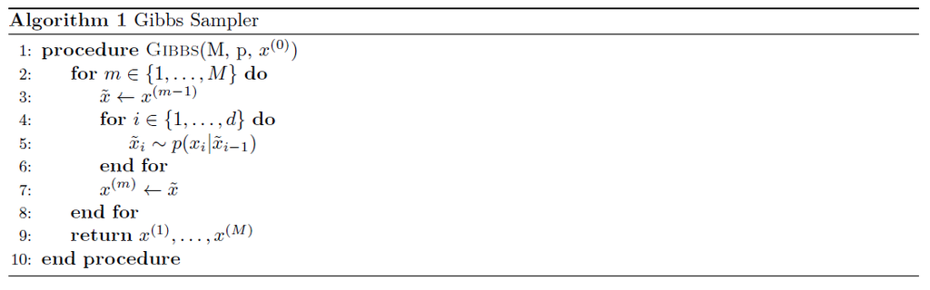

**Click to show code.**

```r
# Gibbs #
# M: total number of samples
# x0: starting location of the Markov Chain
# p: list where the i-th element is the conditional distribution of
#   x_i conditioned on x_-i, should have names doesn't matter what they are
gibbs <- function(M, x0, p) {

  # Setup
  d <- length(x0)
  x <- matrix(x0, nrow=1)

  # x0 is first sample, get M-1 more
  for(m in 2:M){
    x_tilde <- x[m-1,]

    # Sample the next point conditional on the other components
    for(j in 1:d){
      x_tilde[j] <- p[[names(p)[j]]](x_tilde[-j])
    }

    # x_tilde is m-th sample
    x <- rbind(x, x_tilde)
  }

  # output the sample
  return(x)
}
```

The obvious limitation is that we need to know many distributions. Which may not be feasible in practice, or may be very tedious and difficult to implement. Convergence is also slow for poorly-chosen initial values, which in higher dimensions it may be exceeding difficult to choose a good initial value. Convergence is also slow when cor($x_i$, $x_{-i}$) approaches 1.

Gibbs is only really applicable in two or more dimensions. So lets try to sample from the bivariate normal, for which is fairly simple to setup the conditional distributions for.

```r
mu1 <- 1; mu2 <- 2.3; var1 <- 2 ;var2 <- 3; rho <- 0.7
cond1 <- function(x) { rnorm(1, mean=(mu1+rho*sqrt(var1/var2)*(x-mu2)), sd = sqrt((1-rho^2)*var1))}
cond2 <- function(x) { rnorm(1, mean=(mu2+rho*sqrt(var2/var1)*(x-mu1)), sd = sqrt((1-rho^2)*var2))}
gibbs_res <- gibbs(
  M = 5000,
  x0 = c(0,0),
  p = list(p1=cond1, p2=cond2)
)
gibbs_res <- tail(gibbs_res, n=4500) # burn-in of 500
```

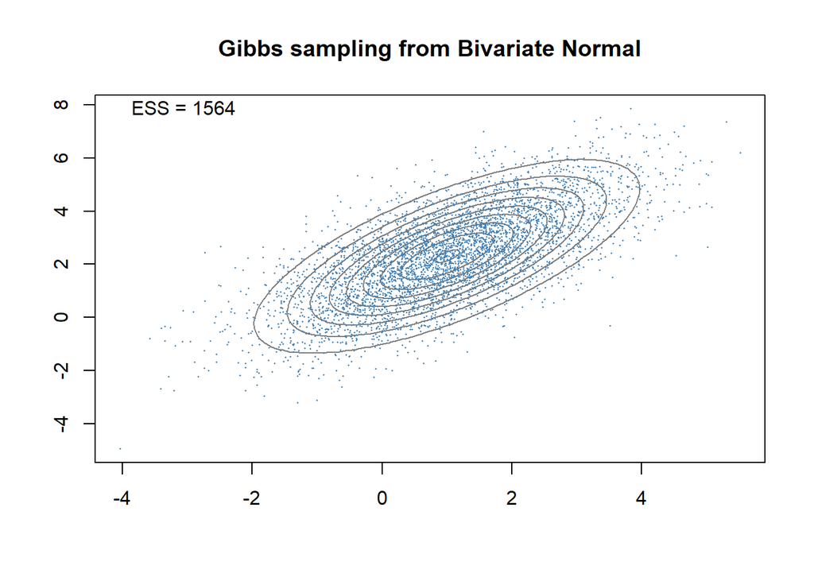

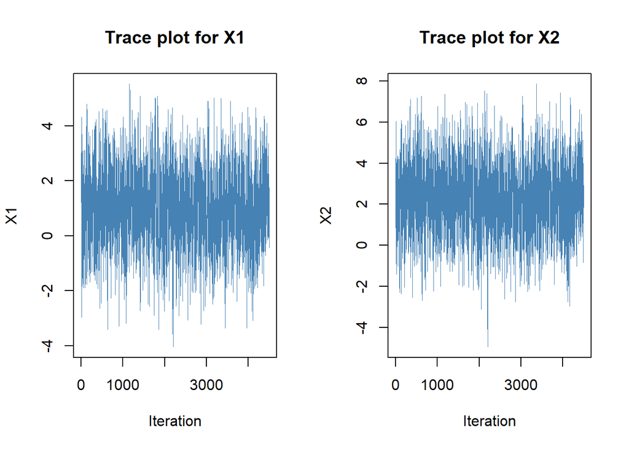

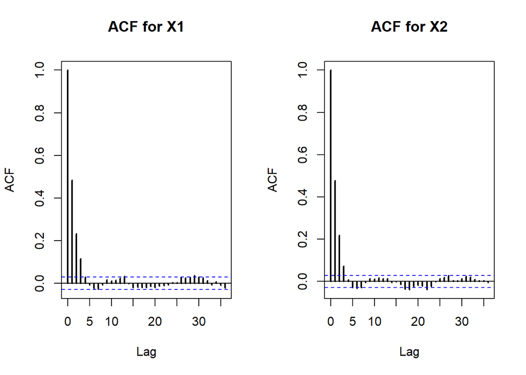

So can see that the trace plots look like Gaussian noise as we would expect. There is some autocorrelation, but nothing concerning. Our effective sample size is about 35% of our MCMC sample size, which is not too bad. I initial thought that was very bad, but after finishing this blog and seeing all of the other results I came back to correct this section. The ESS here is total fine!

#### Metropolis-Hastings (MH)

MH needs only a transition density T, which satisfies two requirements:  
1. We can sample $x\sim T(x|x')$  
2. We have a closed-form (or can evaluate / approximate) the pdf (or pmf) of T  
We then construct our samples by using the transition density to select the new point, and then accepting or rejecting to based on the following acceptance probability:  
$\alpha=min\{1,\frac{p(x_{prop})/T(x_{prop}|x_{curr})}{p(x_{curr})/T(x_{curr}|x_{prop})}\}$  
Where $X_{curr}$ is the current state and we have sampled the proposed next state $x_{prop} \sim T(x|x_{curr})$. If rejected the next state is just set to the current state. Note that we do not technically need the density, something proportional to it will suffice. Suppose we have $r(x)=\frac{p(x)}{Z}$, then:

$min\{1,\frac{r(x_{prop})/T(x_{prop}|x_{curr})}{r(x_{curr})/T(x_{curr}|x_{prop})}\}$  
$=min\{1,\frac{\frac{p(x_{prop})}{Z}/ T(x_{prop}|x_{curr})}{\frac{p(x_{curr})}{Z}/T(x_{curr}|x_{prop})}\}$  
$=min\{1,\frac{p(x_{prop})/T(x_{prop}|x_{curr})}{p(x_{curr})/T(x_{curr}|x_{prop})}\}$  
$=\alpha$

This is very useful for Bayesian inference where one generally does not have the target density, but something proportional to it.

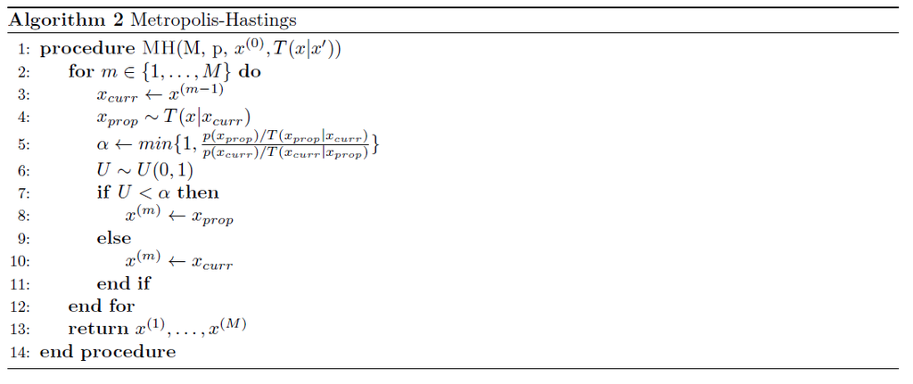

**Click to show code.**

```r
# Metropolis-Hasting (MH)
# M: total number of samples
# x0: starting location of the Markov Chain
# rT: draw from transition distribution gives a sample of x_prop conditional on x_curr
# dT: Transition density function
# p: function that is proportional to the pdf (or pmf) of x
MH <- function(M, x0, rT, dT, p){

  x <- matrix(x0, nrow=1)
  accepts <- 0

  for(m in 2:M){
    x_curr <- x[m-1,]
    x_prop <- rT(x_curr)

    alpha <- min(1, (p(x_prop) / dT(x_prop, x_curr)) / (p(x_curr) / dT(x_curr, x_prop)))

    U <- runif(1)
    if(U < alpha){
      x <- rbind(x, x_prop)
      accepts <- accepts + 1
    } else {
      x <- rbind(x, x_curr)
    }
  }

  list(x = x,
       acc_rate = accepts/(M-1))
}
```

If $x^{(m)}\sim p(x)$ and $x^{(m+1)}|~x^{(m)}\sim MH\{T, x^{(m)}\}$ then $x^{(m+1)}\sim p(x)$. So if the current state follows p(x) and the next state conditional on the current state is given by the MH update, then the next state also follows p(x).  
Proof:  
Let $x_1$ and $x_2$ with $\alpha=\frac{p(x_{1})/T(x_{1}|x_{2})}{p(x_{2})/T(x_{2}|x_{1})}<1$.  
Joint distribution of 1 then 2, so the proposal is accepted ($\alpha \geq 1$):  
$p(x^{(m)}=x_1,x^{(m+1)}=x_2)=p(x_1)\cdot T(x_2|x_1)$  
Joint distribution of 2 then 1, so proposal is accepted with probability $\alpha$.  
$p(x^{(m)}=x_2,x^{(m+1)}=x_1)=p(x_2)\cdot T(x_1|x_2)\frac{p(x_{1})/T(x_{1}|x_{2})}{p(x_{2})/T(x_{2}|x_{1})}$  
$=p(x_1)\cdot T(x_2|x_1)$  
So the joint distribution is symmetric, therefore the each marginal is identical: $p(x^{m+1)})=p(x^{(m)})$, and since we have that $x^{(m)}\sim p(x)$, then we also have that $x^{(m+1)}\sim p(x)$. This tells us that MH will indeed produce a stationary distribution that is equal to the target distribution p(x). With this we can now understand why MH has an acceptance step and how that particular $\alpha$ was chosen. Now, how to know what the optimal acceptance rate is? This found through experimentation. Too low of an acceptance rate and you waste time and end up with many repeat samples. Too high and you are not likely exploring the distribution thoroughly and just “playing it safe”. Unfortunately, the acceptance rate depends on the transition density, so if you want to try something unique you may be in for some work. Luckily the optimal acceptance rate has been found for common and easy to use T.

Lets showcase MH with a 1-dimensional Normal mixture. The one below has $\mu=(-2,3), \sigma=(0.5,1), w=(0.4,0.6)$.

```r
mh_res <- MH(
  M = 5000, x0 = 0,
  rT = function(x) x + rnorm(1, 0, 1),
  dT = function(x, xprop) dnorm(xprop, mean=x, sd=1),
  p  = p1d
)
mh_res$x <- tail(mh_res$x, n=4500) # burn-in of 500
```

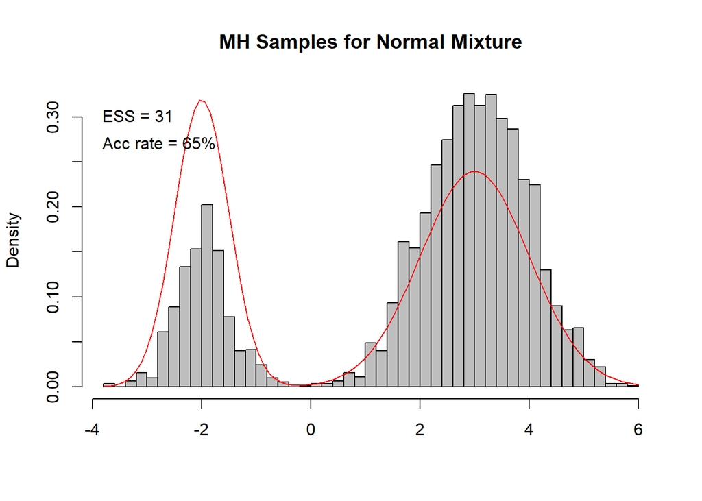

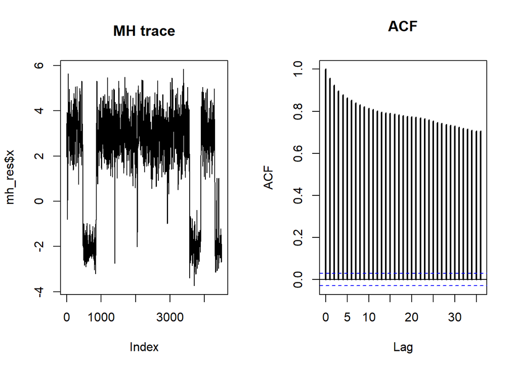

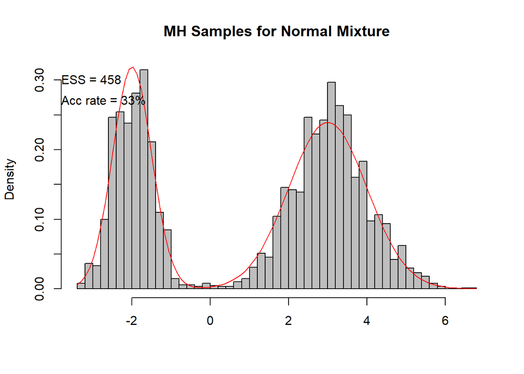

We can see some improvement, which suggests that a lower acceptance rate may be better for this function.

#### Random Walk Metropolis (RWM)

A special case of MH where the transition density is the multivariate normal. So $x_{prop}\sim \mathcal{N}_d(x_{curr},diag(\sigma_{RW}^2))$. Where $\sigma_{RW}^2$ gives the variances of each component, think of it as the “jump-size” of each component in our random walk, the covariances are all taken to be 0. The benefit is that the transition density if now symmetric, so $T(x_{prop}|X_{curr})=T(x_{curr}|X_{prop})$. This means that $\alpha=min\{1,\frac{p(x_{prop})}{p(x_{curr})}\}$. This simplifies MH, and is much easier to use in practice. As we have seen before the transition density in MH does not change the stationary distribution. It does however, change the acceptance rate. Generally there is a target acceptance rate we want to aim for.  
We tune $\sigma_{RW}^2$ such that the acceptance rate is around 25%. This has been shown through experimentation to provide the lowest autocorrelation on average. Ideally all the draws would be completely independent, but the chain structure of the sampling results in some correlation. We can also tune $\sigma_{RW}^2$ while we run the algorithm. There are some options for this, we could tune only during “burn-in”, i.e. the warm-up observations we are going to drop. Or we could have a continuous tuning. Consider two update rules:  
1. $\sigma_{RW}^{(m+1)}=exp(log\sigma_{RW}^{(m)}\pm\delta)$  
2. $\sigma_{RW}^{(m+1)}=exp(log\sigma_{RW}^{(m)}\pm\frac{\delta}{m})$  
We add $\delta$ if previous proposal was accepted, otherwise subtract $\delta$. Scheme 2 may be smarter in practice as the adjustment goes to 0 as m increases. Scheme 1 requires you to decide how long to adjust for, there is no good way outside of trail and error to decide that. The adaption step does not make this fool proof, terrible choices of $\sigma_{RW}^{(0)}$ or $x^{(0)}$ will still cause poor performance.

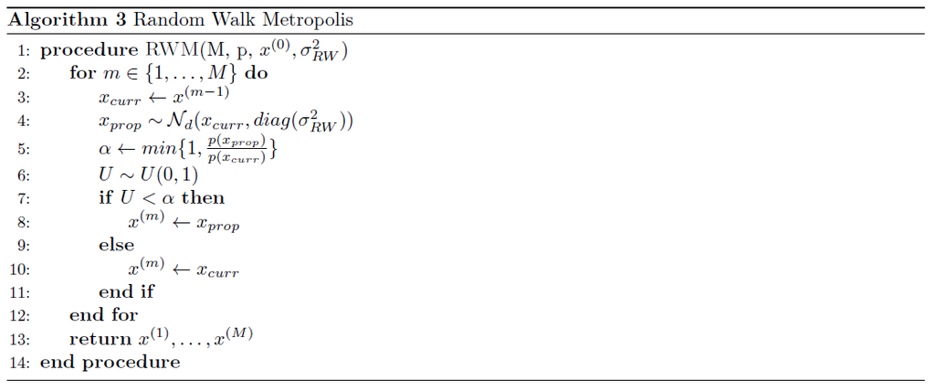

**Click to show code.**

```r
# Random Walk Metropolis (RWM)
# M: total number of samples
# x0: starting location of the Markov Chain
# sigma_tune: vector of variances of each x in the mv-normal
# p: function that is proportional to the pdf (or pmf) of x
RWM <- function(M, x0, sigma_tune, p){

  x <- matrix(x0, nrow=1)
  accepts <- 0

  if(length(sigma_tune) == 1){
    Sigma <- as.matrix(sigma_tune)
  } else {
    Sigma <- diag(sigma_tune)
  }

  for(m in 2:M){
    x_curr <- x[m-1,]
    x_prop <- as.numeric(rmvnorm(n=1, mean=x_curr, sigma = Sigma))

    alpha <- min(1, p(x_prop) / p(x_curr))

    U <- runif(1)
    if(U < alpha){
      x <- rbind(x, x_prop)
      accepts <- accepts + 1
    } else {
      x <- rbind(x, x_curr)
    }
  }

  list(x = x,
       acc_rate = accepts/(M-1))
}
```

Lets use that same Normal mixture function to show RWM.

```r
rwm_res <- RWM(
  M = 5000,
  x0 = 0,
  sigma_tune = 40, # Yes, the variance is 40 that is what it took to get 25% acc rate
  p = p1d
)
rwm_res$x <- tail(rwm_res$x, n = 4500)
```

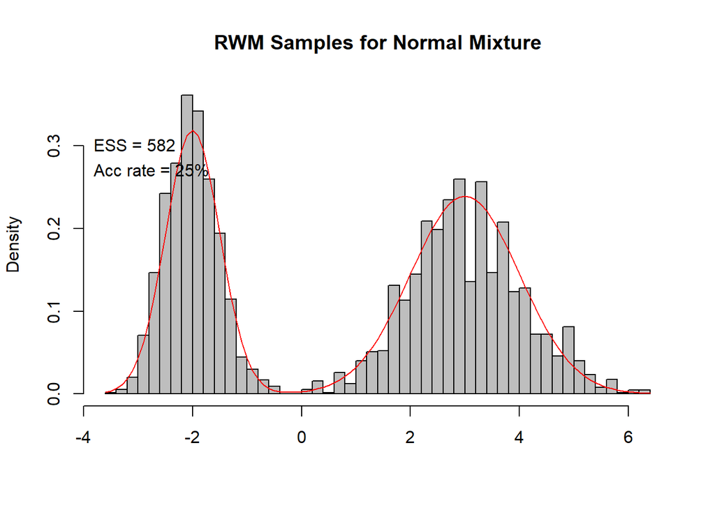

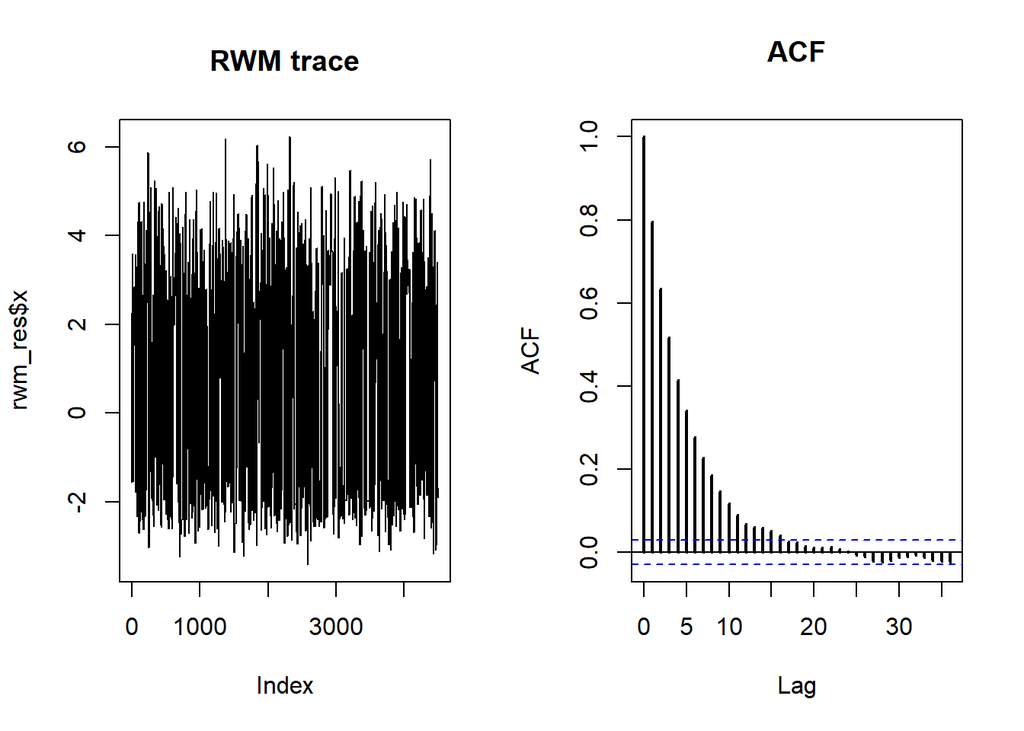

There is some autocorrelation, but nothing concerning. The acceptance rate is spot on, the ESS is about 13% of the sample, which seems bad. However it seems that this may be very typical for these algorithms, on functions like this one, that is disjointed and may be difficult to sample. This is better than the MH, mainly because I did not have to guess at what might be a good value and adjusted $\sigma$ up and down based on what the resulting acceptance rate was.

#### Metropolis within Gibbs (MWG)

The main drawback of the Gibbs Sampler is the requirement to be able to sample from many conditional distributions. This is alleviated by Metropolis-within-Gibbs (MWG). MWG replaces all the conditional distributions with the univariate normal distribution. So the update becomes $x_{prop,j}\sim\mathcal{N}(x_{curr,j},\sigma^2_{RW,j})$. How MWG differs from RWM is that the acceptance is done component wise, so rather than the entire step being accepted or rejected, the decision is made separately for each component. The optimal component-wise acceptance rate is 45%. Generally, it is recommended to use MWG instead of RWM. We can again adjust $\sigma^2_{RW,j}$ as we did in RWM, to get the optimal acceptance rate.

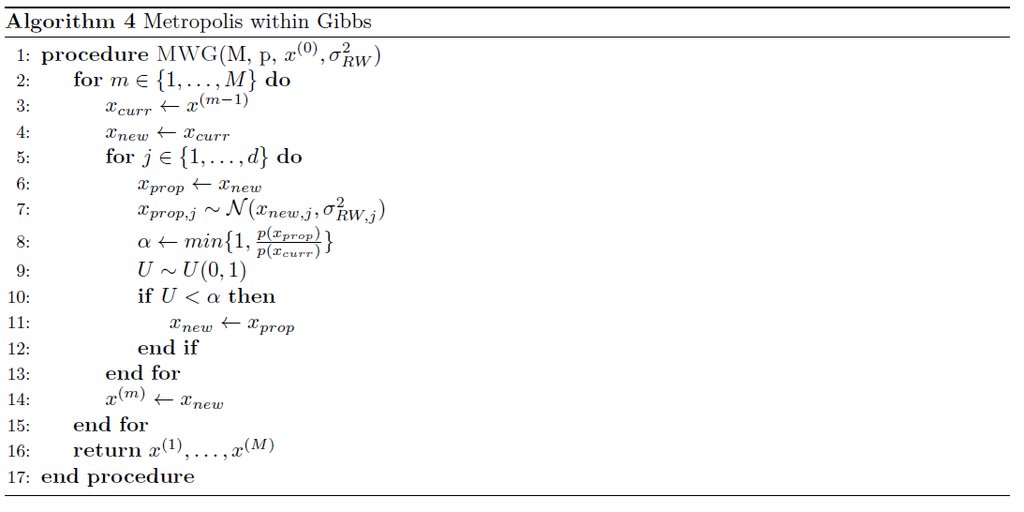

**Click to show code.**

```r
# Metropolis within Gibbs (MWG)
# M: total number of samples
# x0: starting location of the Markov Chain
# sigma_tune: vector of variances of each x in the mv-normal
# p: function that is proportional to the pdf (or pmf) of x
MWG <- function(M, x0, p, sigma_tune) {

  # Setup
  d <- length(x0)
  x <- matrix(x0, nrow=1)
  sd_tune <- sqrt(sigma_tune)
  accepts <- 0

  # x0 is first sample, get M-1 more
  for(m in 2:M){
    x_curr <- x[m-1,]
    x_new <- x_curr

    for(j in 1:d){
      x_prop <- x_new
      x_prop[j] <- rnorm(n=1, mean=x_new[j], sd=sd_tune[j])

      alpha <- min(1, p(x_prop) / p(x_new))

      if(runif(1) < alpha){
        x_new <- x_prop   # accept the proposal
        accepts <- accepts + 1
      }
    }

    # x_new is m-th sample
    x <- rbind(x, x_new)
  }

  # component-wise acceptance rate
  acc_rate <- accepts / (d * (M-1) )

  # output the sample
  list(x = x,
       acc_rate = acc_rate)
}
```

Since this is Gibbs based lets use a 2d function. Since we do not need to specify the conditionals lets do something more complicated and use a 2d Normal Mixture. This one has $\mu_1=(0,0), \mu_2=(3,3)$, $\Sigma_1=I_2$ and $\Sigma_2$ has both variances at 1, covariance at 0.8. I am keeping $\sigma^2_{RW}$ as a scalar multiple of the identity, this is not required and is done only for simplicity.

```r
mwg_res <- MWG(
  M = 5000,
  x0 = c(0,0),
  p = p2d,
  sigma_tune = c(1,1)*3.85
)
mwg_no_burnin <- mwg_res$x
mwg_res$x <- tail(mwg_res$x, n=3500)
```

Here we can see one utility of the trace plot. We can see that dropping only the first 500 iterations as we’ve been doing is not enough here. We should instead drop the first 1500 based on this.

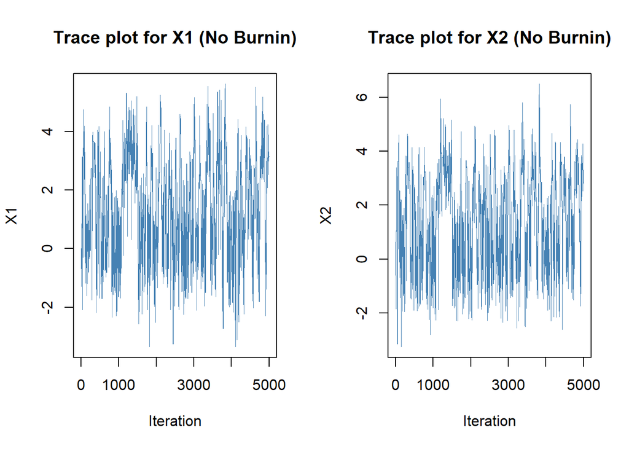

Now they look much better:

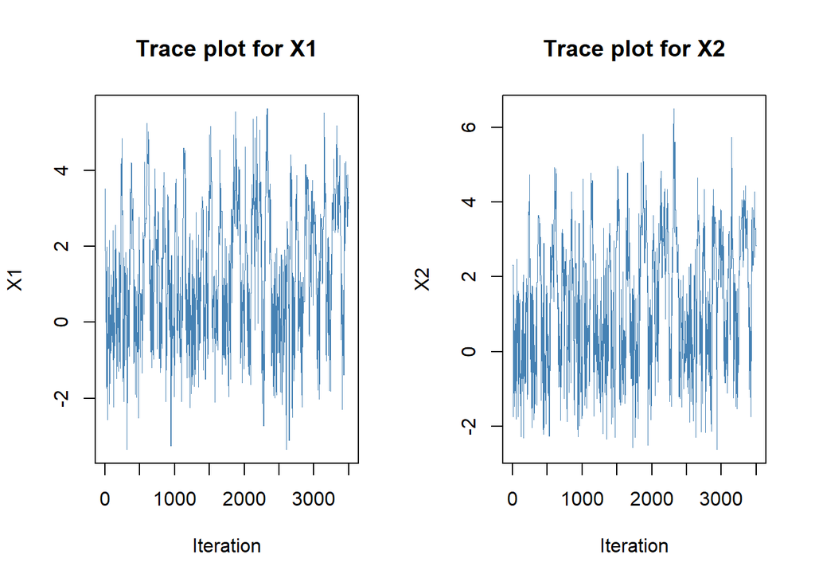

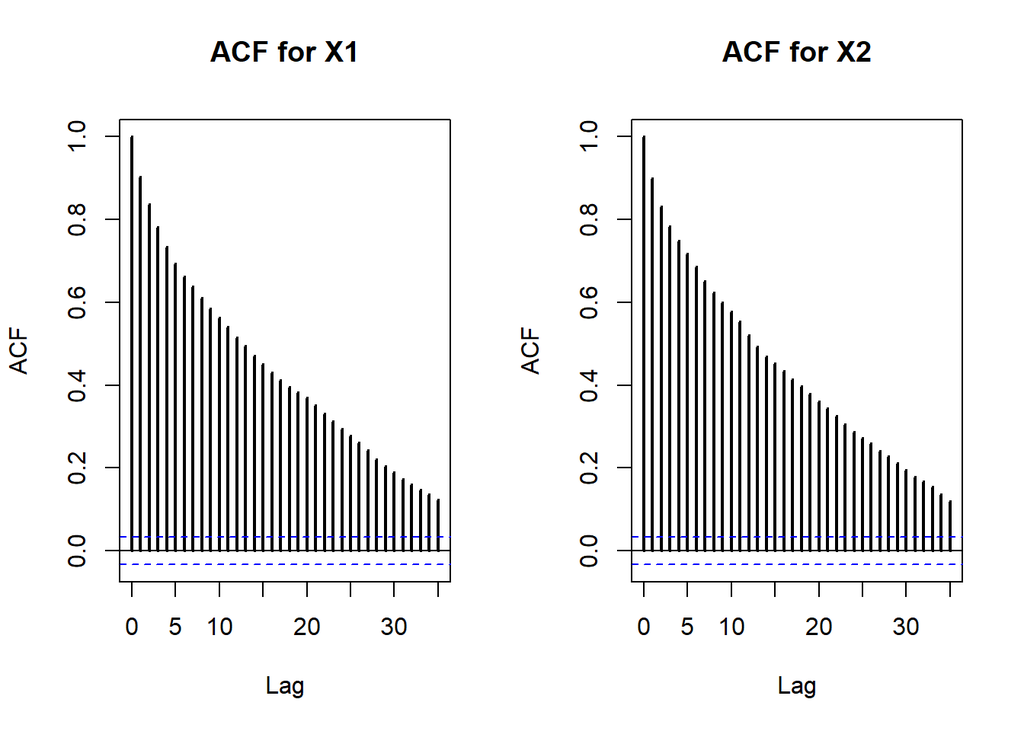

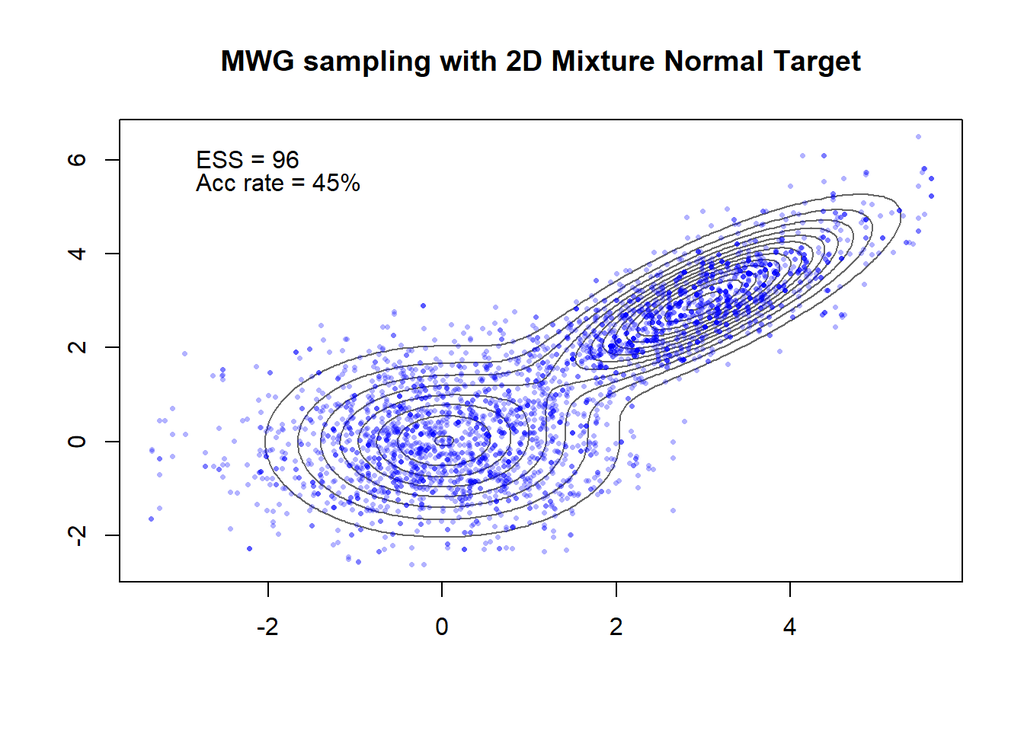

The acceptance rate is on target. But! The ESS is low, this shows us that acceptance rate being “optimal” does not mean we will get good results. We can see that there is perhaps some notable autocorrelation, though the trace plot seemed like it was getting stuck when I only dropped the first 500 obs. I changed that to 1500 and now the trace plots look great! The ESS did not change, so that mean it got larger wrt to the sample size. Playing around with $\sigma^2_{RW}$ I did not really get higher than ESS = 100 here. So again, I may just be using a difficult function here. The two components of this function are positively correlated but MWG does not give us a way to directly use that correlation. We could consider possibly changing the algorithm to instead sample from a conditional normal or use a copula to induce that correlation.

### Hamiltonian Monte Carlo (HMC)

HMC is an extensions of MCMC which uses Hamiltonian Dynamics rather than some density to choose the next sample in the chain. If you, like me, have not taken physics since highschool do not worry! For I will try to paint a clear visual for you. Imagine some function that is proportional to the density. Now flip it upside down. What to you have? A skate park. In this skate park there is a hockey puck. There is no friction. The hockey puck is going to blast off in some direction, its’ velocity and direction are drawn from the multivariate normal. After a fixed time it will stop, that location is the next sample. This process is repeated until we have all our samples. I only understood HMC only after I saw the 3D simulation in this [blog](https://arogozhnikov.github.io/2016/12/19/markov_chain_monte_carlo.html), it made what was happening very clear. If my skate park analogy did not make sense consider seeing the animation in action.

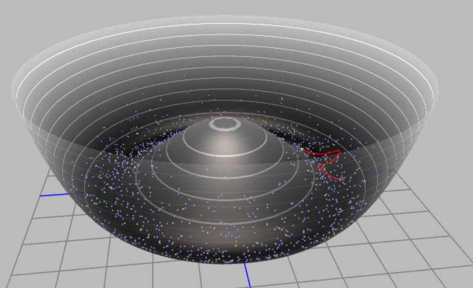

Figure 1: Blue points are true samples. Green points are generated samples. The large green point is the current location. The red line shows the trajectory. Where it stops is the next sample. It is more likely to stop in the ‘lower’ areas which correspond to a higher density.

Unlike MH we do not need an acceptance step, theoretically. We will see that in practice we do need one, more on that below. Now, dear reader, you may be wondering “why does this work?” and “why don’t you prove it?”. These are both excellent questions. If you asked these questions, congratulations! You ask excellent questions. Now let’s move on.

#### Hamiltonian Dynamics

In physics, the Hamiltonian is $\mathcal{H}(p,q)=\mathcal{U}(q)+\mathcal{K}(p)$, where  
1. $\mathcal{U}(q)$ is the potential energy proportional to position q.  
2. $\mathcal{K}(p)=\frac{p^2}{2m}$ is the kinetic energy from momentum p, and m is the mass of the puck.  
One characteristic of Hamiltonian dynamics is the energy is conserved. So $\mathcal{H}(p_t,q_t)$ remains constant for all time t.

#### Regular HMC

In practice HMC has two main differences from Metropolis-Hastings:  
1. The next proposed state is generated through the Hamiltonian Dynamics simulation, rather than drawn from a distribution.  
2. The acceptance probability $\alpha$ is different.  
Outside of this the two algorithms are largely the same.  
First step in choosing the next state is to sample the momentum from the multivariate normal, $v\sim\mathcal{N}_d(0,M)$. Where M, also called the ‘Mass matrix’, gives the variance-covariance of v. For a simple implementation we take M to be diagonal, for an even simpler implementation we can take M to be the identity. $M=I_d$ works well enough in practice. According to the paper by Radford Neal (2012) the inverse of the mass matrix should be the variance matrix of the target distribution, so $M=(var(X))^{-1}$. Which we can estimate after getting enough samples, more on that later. Now that we have the initial momentum we must use this to get the next state. We adopt Hamiltonian dynamics as follows.  
For our purposes we set:  
1. $\mathcal{U}(x)=-log\rho(x)$. So as $\rho(x)$ approaches 0 the potential energy approaches $\infty$. Think back to the image and the hockey puck analogy. Lower $\rho(x)$ corresponds to higher points on the ramp, which means the puck will fall faster out of those points, so we sample less at lower density points.  
2. $\mathcal{K}(v)=\frac{1}{2}v^TM^{-1}v$, this allows for a general mass matrix.  
This leads to the following ODEs:  
$\frac{d}{dt}x_i(t)=[M^{-1}v(t)]_i$, $\frac{d}{dt}v_i(t)=\frac{\partial}{\partial x_i}log\rho(x)$  
There is no general analytical solution to these ODEs. So we approximate them using leap-frog integration. However, since we use an approximation, we can no longer guarantee that the Hamiltonian remains constant.  
A single leap-frog integrator step is given by:  
$v_\epsilon=v+\frac{\epsilon}{2}\cdot\nabla log\rho(x)$  
$\tilde x=x+\epsilon\cdot M^{-1}v_\epsilon$  
$v=v_\epsilon +\frac{\epsilon}{2}\cdot\nabla log\rho(\tilde x)$  
Where $\nabla log\rho(x)$ is the gradient vector. We take L steps to arrive at our destinations. Some literature suggests that we should fix $L\epsilon=1$ so that the integration time it always 1. More recent implementations let L and $\epsilon$ vary independently, so can get longer or shorter paths, as fits the situation best.

Now that we have the proposed state we must decide if we will accept it. We use:  
$\alpha=min\{1,\frac{exp(\mathcal{H}(\Gamma_0))}{exp(\mathcal{H}(\Gamma_{prop}))}\}$  
Where $\Gamma_i=(x_i,v_i)$.  
Theoretically, since energy is conserved we should have $\mathcal{H}(\Gamma_0)=\mathcal{H}(\Gamma_{prop})$, however as stated before this is not true in practice as we only approximate the ODE. Thus the acceptance step becomes needed, though it is only there to compensate for small errors and the acceptance rate is generally quite high; which leads to a more efficient algorithm.

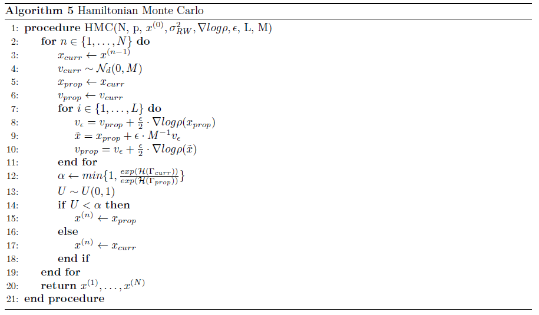

**Click to show code.**

```r
# Base HMC
# M: total number of samples
# x0: starting location of the Markov Chain
# p: function that is proportional to the pdf (or pmf) of x
# grad_log_p: gradient of log p(x) wrt x
# L: number of steps in the leap frog integration
# epsilon: step size of the leap frog integration
# mass: variance-covariance matrix of Normal the momentum is drawn from
HMC <- function(M, x0, p, grad_log_p, L, epsilon, mass=NULL) {

  # Setup
  d <- length(x0)
  x <- matrix(x0, nrow=1)
  accepts <- 0

  # if mass if NULL, then make mass matrix identity
  if(is.null(mass)) {
    mass <- diag(rep(1, times=d))
  }

  # x0 is first sample, get M-1 more
  for(m in 2:M){
    x_curr <- x[m-1,]
    v_curr <- as.numeric(rmvnorm(n=1, mean=rep(0, times=d), sigma = mass))

    x_prop <- x_curr
    v_prop <- v_curr

    # Generate next with Leap-Frog Integrator

    for(i in 1:L){
      v_prop <- v_prop + 0.5 * epsilon * grad_log_p(x_prop)
      x_prop <- x_prop + epsilon * drop(solve(mass, v_prop))
      v_prop <- v_prop + 0.5 * epsilon * grad_log_p(x_prop)
    }
    # for reversibility
    v_prop <- -v_prop

    # MH acceptance step
    K0 <- drop(crossprod(v_curr, solve(mass, v_curr)))
    K1 <- drop(crossprod(v_prop, solve(mass, v_prop)))
    diff_H <- log(p(x_prop)) - log(p(x_curr)) + 0.5 * (K0 - K1)
    alpha <- min(1, exp(diff_H))


    if(runif(1) < alpha){
      x <- rbind(x, x_prop)
      accepts <- accepts + 1
    } else {
      x <- rbind(x, x_curr)
    }
  }

  # output the sample
  list(x = x,
       acc_rate = accepts / (M-1))
}
```

Now an obvious concern is that if the target density is disjoint then there is a insurmountable wall separating two parts of the density, that our brave hockey puck cannot get over. One solution to this is tempering. For the first half of the leapfrog steps we scale velocity up by a tempering factor $\lambda$. So $v_{next}=\lambda v$. Then in the second half we scale it back down $v_{next}=\frac{1}{\lambda}v$. I did not find any rule of thumb or adjustment technique for $\lambda$. The value is typically low, $1\leq\lambda\leq1.05$ is a reasonable range. The same goes for $\epsilon$ and L. $\epsilon = 0.1$ and $L=10$ are reasonable starting values, you may have to adjust based on performance. But, surely there must be a way to have the algorithm adjust itself? There is! In the next section I will present the Dual-Averaging technique for adjusting $\epsilon$.

Now lets see how HMC performs (you will notice there was some foreshadowing in the last paragraph). Again we will use the 1D normal mixture. I feel that is difficult enough. After some experimentation I have interesting results. I tried many combinations of $\epsilon$ and L. I chose $L=10, \epsilon=0.7$, this gives ESS 120. If I set L to 16 that drops to 19. L = 11 results in ESS = 45 So this is difficult to tune and very sensitive to small changes.

```r
hmc_res <- HMC(
  M = 5000,
  x0 = 2,
  p = p1d,
  grad_log_p = grad_logp1d,
  L = 10,
  epsilon = 0.7
)

hmc_res$x <- tail(hmc_res$x, n = 4500)
```

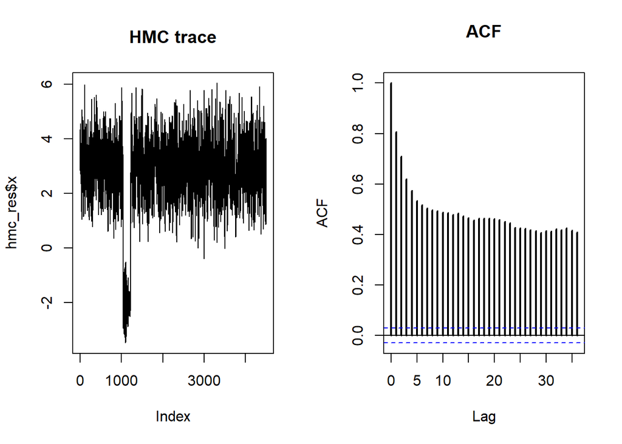

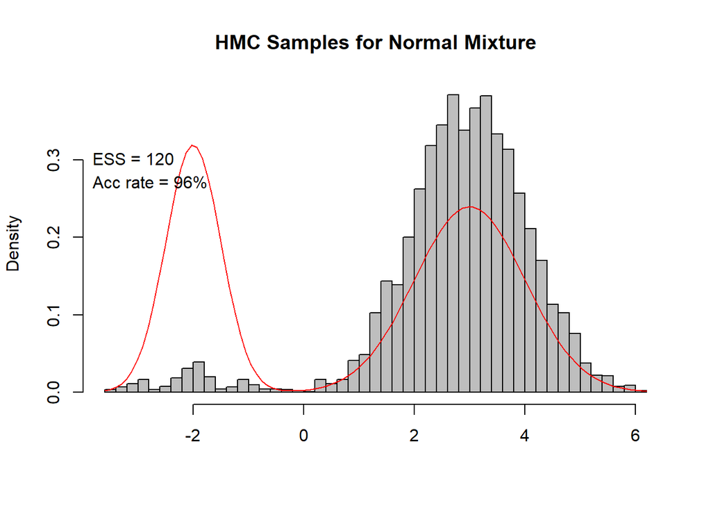

As you can see this is doing terrible. It only briefly samples the left normal and gets stuck in the right side normal. The autocorrelation is also high. Going back to the skate park analogy, it seems the ‘wall’ in the middle is too steep and high for the hockey puck to consistently cross.

Let’s take it easy on HMC and give it a function that will not be so difficult to sample from. Still a normal mixture but the two normals overlap significantly which should make it much easier.

```r
hmc_res_e <- HMC(
  M = 5000,
  x0 = 2,
  p = p1de,
  grad_log_p = grad_logp1de,
  L = 10,
  epsilon = 0.97
)

hmc_res_e$x <- tail(hmc_res_e$x, n = 4500)
```

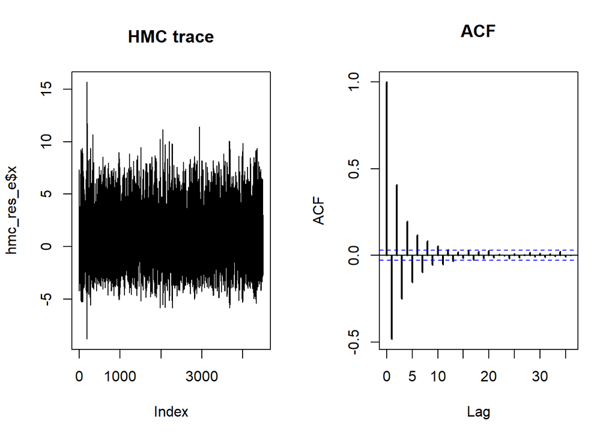

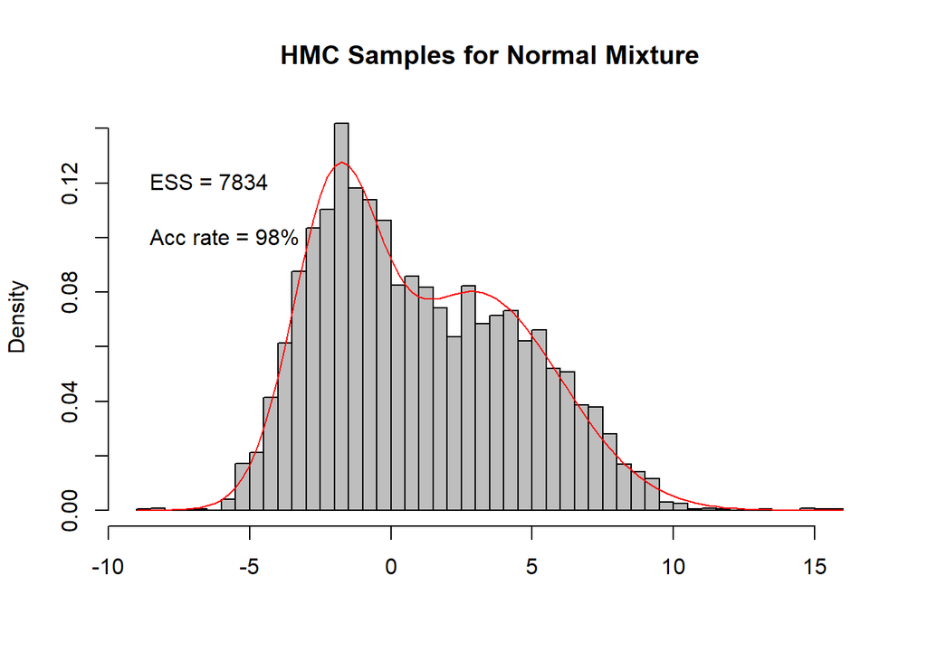

Much better! There is some serious negative correlation as well. This is why ESS is larger than the sample size. The acceptance rate is also close to 98%. Both of these things put together mean that HMC is extremely efficient, when it is a good fit for the problem.

#### HMC with Dual-Averaging (DA)

We want to dynamically choose $\epsilon$. Too small results in taking many tiny steps which is inefficient, too large results in a larger deviation in $\mathcal{H}$ and thus more rejections. HMC defines the following statistics:  
$H_t^{MHC}=min\{1,\frac{p(x_{prop},v_{prop})}{p(x_{curr},v_{curr})}\}$; $h^{HMC}(\epsilon)=\mathbb{E}_t(H_t^{HMC}|\epsilon)$  
So $H_t^{HMC}$ is the acceptance probability at the t-th iteration and $h^{HMC}$ is the expected average acceptance probability. We want to get $h^{HMC}=\delta$ for some $\delta\in(0,1)$. The update rules are rather complicated, full proofs can be found in [this paper by Hoffman and Gelman (2011)](https://arxiv.org/pdf/1111.4246).

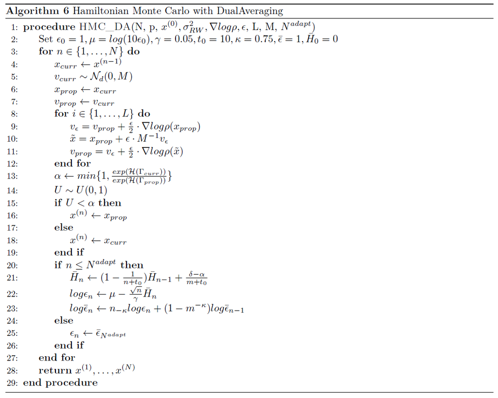

**Click to show code.**

```r
# HMC with Dual-Averaging
# M: total number of samples
# x0: starting location of the Markov Chain
# p: function that is proportional to the pdf (or pmf) of x
# grad_log_p: gradient of log p(x) wrt x
# lambda: integration time for leap frog integrator
# epsilon: initial step size of the leap frog integration
# mass: variance-covariance matrix of Normal the momentum is drawn from
# burnin: number of iterations for which epsilon is allowed to adjust
# delta: target acceptance ratio
HMC_DA <- function(M, x0, p, grad_log_p, lambda = 1, epsilon, mass=NULL, burnin = floor(M/2), delta=0.65) {

  # Setup
  d <- length(x0)
  x <- matrix(x0, nrow=1)
  accepts <- 0

  # if mass if NULL, then make mass matrix identity
  if(is.null(mass)) {
    mass <- diag(rep(1, times=d))
  }

  # Dual-Averaging parameters
  gamma <- 0.05
  t0  <- 10
  kappa <- 0.75

  mu <- log(10 * epsilon)
  H_bar <- 0
  epsilon_bar <- 1

  # x0 is first sample, get M-1 more
  for(m in 2:M){
    x_curr <- x[m-1,]
    v_curr <- as.numeric(rmvnorm(n=1, mean=rep(0, times=d), sigma = mass))

    x_prop <- x_curr
    v_prop <- v_curr

    # Generate next with Leap-Frog Integrator

    L_m <- max(1, round(lambda/epsilon))

    for(i in 1:L_m){
      v_prop <- v_prop + 0.5 * epsilon * grad_log_p(x_prop)
      x_prop <- x_prop + epsilon * drop(solve(mass, v_prop))
      v_prop <- v_prop + 0.5 * epsilon * grad_log_p(x_prop)
    }


    # MH acceptance step
    K0 <- drop(crossprod(v_curr, solve(mass, v_curr)))
    K1 <- drop(crossprod(v_prop, solve(mass, v_prop)))
    diff_H <- log(p(x_prop)) - log(p(x_curr)) + 0.5 * (K0 - K1)
    alpha <- min(1, exp(diff_H))


    if(runif(1) < alpha){
      x <- rbind(x, x_prop)
      accepts <- accepts + 1
      # for reversibility, only if accepted in HMC with DA
      v_prop <- -v_prop
    } else {
      x <- rbind(x, x_curr)
    }

    # Dual Averaging updates, only during burn-in
    if (m <= burnin) {
      # Running average of (target - acceptance)
      H_bar <- (1 - 1/(m + t0)) * H_bar + (1/(m + t0)) * (delta - alpha)

      # Raw epsilon update
      epsilon <- exp(mu - (sqrt(m) / gamma) * H_bar)

      # Smoothed epsilon_bar update
      eta <- m^(-kappa)
      epsilon_bar <- exp((1 - eta)*log(epsilon_bar) + eta*log(epsilon))

    } else if (m == burnin + 1) {
      # Freeze epsilon to final tuned value at end of burnin
      epsilon <- epsilon_bar
    }
  }

  # output the sample
  list(x = x,
       acc_rate = accepts / (M-1))
}
```

Alright now lets try it out on our 1D normal mixture.

```r
hmc_da_res <- HMC_DA(
  M = 5000,
  x0 = 0,
  p = p1d,
  grad_log_p = grad_logp1d,
  lambda = 1,
  epsilon = 0.05,
  delta = 0.7
)

hmc_da_res$x <- tail(hmc_da_res$x, n = 4500)
```

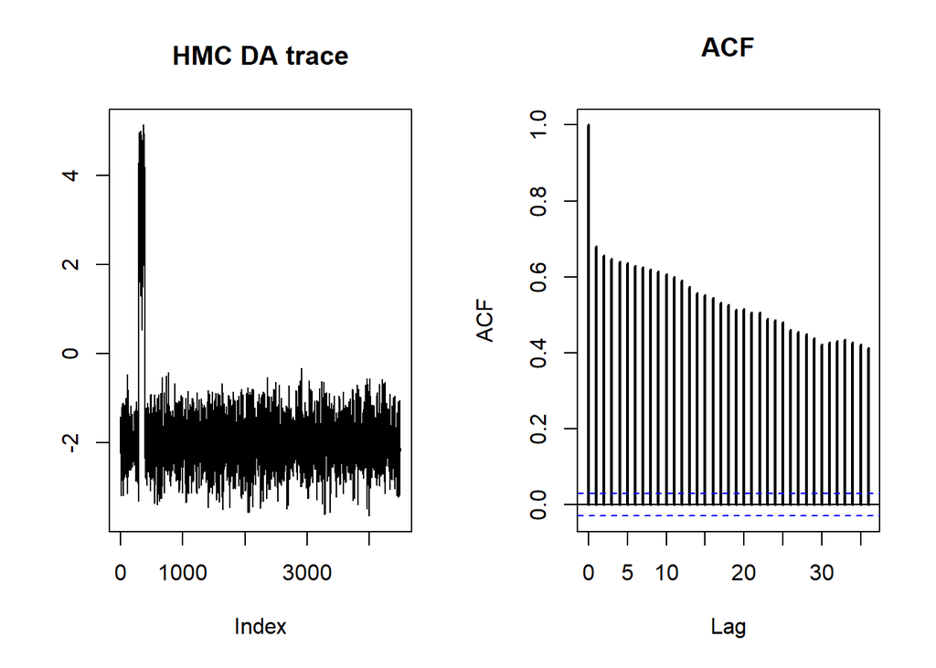

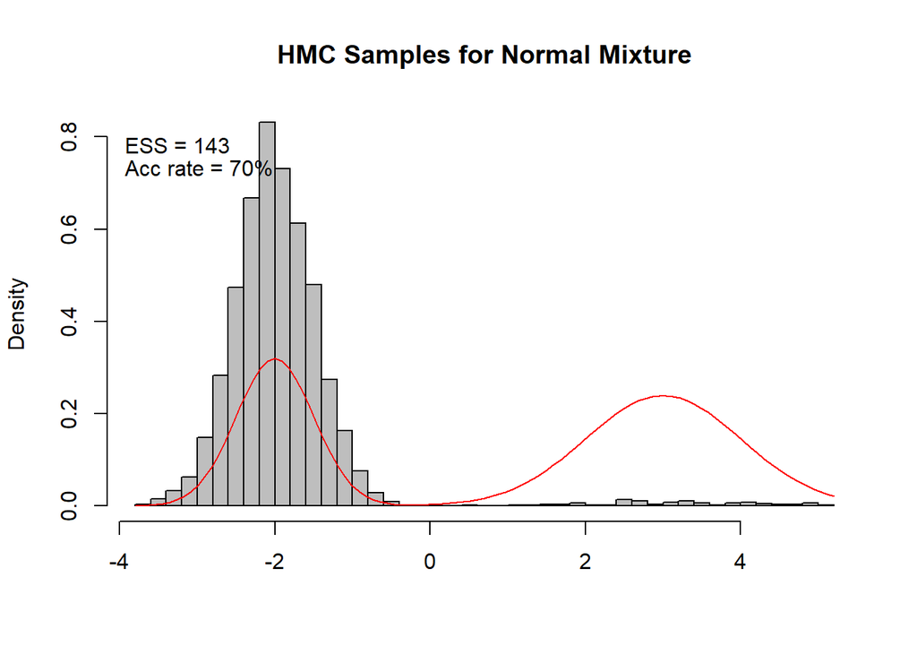

As you can see this is very bad. Disjoint functions seem to be big weakness for HMC. As with regular HMC, let’s have mercy and try it out on the easier function.

```r
hmc_da_res_e <- HMC_DA(
  M = 5000,
    x0 = 0,
    p = p1de,
    grad_log_p = grad_logp1de,
    lambda = 9.7,
    epsilon = 0.22,
    delta = 0.65
)

hmc_da_res_e$x <- tail(hmc_da_res_e$x, n = 4500)
```

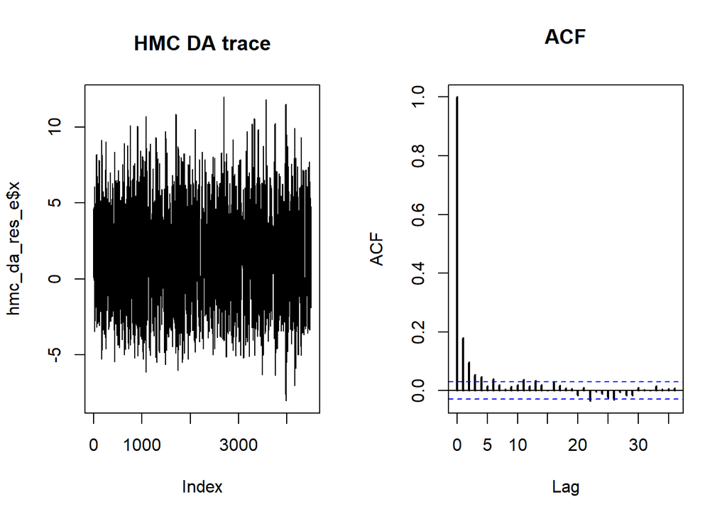

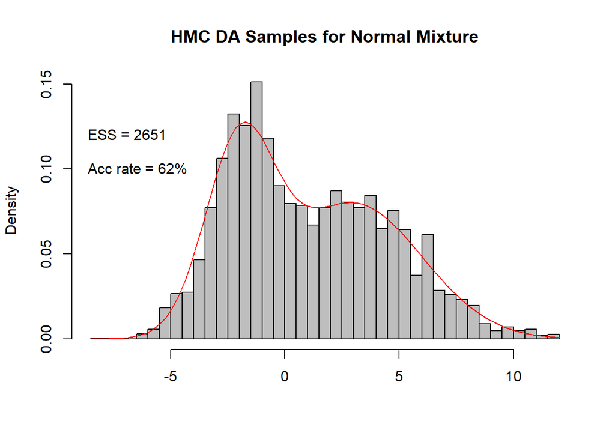

Again, much better performance. We have very little autocorrelation. We did not get the negative autocorrelation as before. I am not sure how exactly that happened. Is there a way to induce negative autocorrelation in the sampling scheme? That is a good question to ask, I do not have an answer (yet).

As alluded before, we can also adjust the mass matrix M. To do this we run in four stages as opposed to two.  
Stage 1: Dual-Averaging to find $\bar\epsilon$.  
Stage 2: Setting the Mass. $M \gets [Var(X)]^{-1}$, as calculated by our samples. We can run at this stage for awhile and slowly set M based on samples only in this stage, as we are hopefully close to the target distribution.  
Stage 3: Dual-Averaging again to adjust $\bar\epsilon$ for the new M.  
Stage 4: No more adjustment, just get more samples.

Thank you for reading! <3

#### Sources

I used my own notes from the University of Waterloo courses: STAT340 and CS476.  
I used course materials for STAT946 I found online:  
https://mlysy.github.io/stat946/basics-of-markov-chain-monte-carlo.html  
https://mlysy.github.io/stat946/hamiltonian-monte-carlo.html  
This blog: https://arogozhnikov.github.io/2016/12/19/markov_chain_monte_carlo.html  
And of course Hoffman and Gelman:  
Hoffman, Matthew D., and Andrew Gelman. 2011. “The No-u-Turn Sampler: Adaptively Setting Path Lengths in Hamiltonian Monte Carlo.” https://arxiv.org/abs/1111.4246.